# Decision Trees and Machine Learning

Decision trees are tree structures containing rules

The leaf nodes of the tree are the "learned" categories (or threshold values)

A path from the root to a leaf node represents a rule

## Types of decision trees

- **Classification trees**: Uses rules to classify cases into two or more categories (Rocks vs Mines)
  - Classification trees recursively split the data on a feature value
  - Each split minimizes the cost (also known as the impurity)
  - Cost is commonly measured using the GINI cost function (a measure of the probability of misclassification or 'purity')
- **Regression trees**: Uses rules to group data into target variable ranges (Wine Quality)
  - Also split the data on feature values
  - Minimize cost (impurity). Usually the mean squared error

### Stopping and Pruning Rules

A minimum count of observations in each leaf node

A maximum tree **depth**

A maximum **complexity** (the number of splits)

## Predicting wine quality using a decision tree

### Import the data

```python
url = "http://archive.ics.uci.edu/ml/machine-learning-databases/wine-quality/winequality-red.csv"
import pandas as pd
from pandas import DataFrame
w_df = pd.read_csv(url,header=0,sep=';')
w_df.describe()
```

|  | fixed acidity | volatile acidity | citric acid | residual sugar | chlorides | free sulfur dioxide | total sulfur dioxide | density | pH | sulphates | alcohol | quality |
| --- | --- | --- | --- | --- | --- | --- | --- | --- | --- | --- | --- | --- |
| count | 1599.000000 | 1599.000000 | 1599.000000 | 1599.000000 | 1599.000000 | 1599.000000 | 1599.000000 | 1599.000000 | 1599.000000 | 1599.000000 | 1599.000000 | 1599.000000 |
| mean | 8.319637 | 0.527821 | 0.270976 | 2.538806 | 0.087467 | 15.874922 | 46.467792 | 0.996747 | 3.311113 | 0.658149 | 10.422983 | 5.636023 |
| std | 1.741096 | 0.179060 | 0.194801 | 1.409928 | 0.047065 | 10.460157 | 32.895324 | 0.001887 | 0.154386 | 0.169507 | 1.065668 | 0.807569 |
| min | 4.600000 | 0.120000 | 0.000000 | 0.900000 | 0.012000 | 1.000000 | 6.000000 | 0.990070 | 2.740000 | 0.330000 | 8.400000 | 3.000000 |
| 25% | 7.100000 | 0.390000 | 0.090000 | 1.900000 | 0.070000 | 7.000000 | 22.000000 | 0.995600 | 3.210000 | 0.550000 | 9.500000 | 5.000000 |
| 50% | 7.900000 | 0.520000 | 0.260000 | 2.200000 | 0.079000 | 14.000000 | 38.000000 | 0.996750 | 3.310000 | 0.620000 | 10.200000 | 6.000000 |
| 75% | 9.200000 | 0.640000 | 0.420000 | 2.600000 | 0.090000 | 21.000000 | 62.000000 | 0.997835 | 3.400000 | 0.730000 | 11.100000 | 6.000000 |
| max | 15.900000 | 1.580000 | 1.000000 | 15.500000 | 0.611000 | 72.000000 | 289.000000 | 1.003690 | 4.010000 | 2.000000 | 14.900000 | 8.000000 |

#### Build train and test samples

```python
from sklearn.model_selection import train_test_split
train, test = train_test_split(w_df, test_size = 0.3)
x_train = train.iloc[0:,0:11]
y_train = train[['quality']]
x_test = test.iloc[0:,0:11]
y_test = test[['quality']]

#Use all data for cross validation
x_data = w_df.iloc[0:,0:11]
y_data = w_df[['quality']]
#x_data
print("Length of test data: ",len(y_test)," rows")
y_test.head()
```

```
Length of test data:  480  rows
```

|  | quality |
| --- | --- |
| 193 | 5 |
| 921 | 6 |
| 318 | 7 |
| 975 | 5 |
| 178 | 5 |

### Classifiers vs Regressors

Decision tree regressors are used when the target variable is continuous and ordered (wine quality from 0 to 10)

Classifiers are used when the target variable is a set of unordered categories (rocks or mines)

```python
from sklearn.tree import DecisionTreeRegressor
from sklearn import tree

model = DecisionTreeRegressor(max_depth = 3)
model.fit(x_train,y_train)
```

```
DecisionTreeRegressor(criterion='mse', max_depth=3, max_features=None,
                      max_leaf_nodes=None, min_impurity_decrease=0.0,
                      min_impurity_split=None, min_samples_leaf=1,
                      min_samples_split=2, min_weight_fraction_leaf=0.0,
                      presort=False, random_state=None, splitter='best')
```

```python
#Get the R-Square for the predicted vs actuals on the text sample
print("Training R-Square",model.score(x_train,y_train))
print("Testing R-Square",model.score(x_test,y_test))
```

```
Training R-Square 0.3424386355812266
Testing R-Square 0.2822210205487822
```

### Download and install [graphviz](http://www.graphviz.org/Download.php)

If you are having issues using Graphviz in Windows, then try the following steps:

1. 1. Install Graphviz
2. 2. After installing graphviz, add it to the Computer's Path.
   - Go to PC properties
   - Click environment variables in the advanced settings section
   - Add C:\Program Files (x86)\Graphviz2.38\bin\ to the PATH and click Apply
3. Install Pydotplus. Install pydot after graphviz as Pydot is Graphviz's dot language and needs Graphviz for reference.

### Install pydotplus (using pip): Install graphviz before pydotplus!

```python
!pip install pydotplus
```

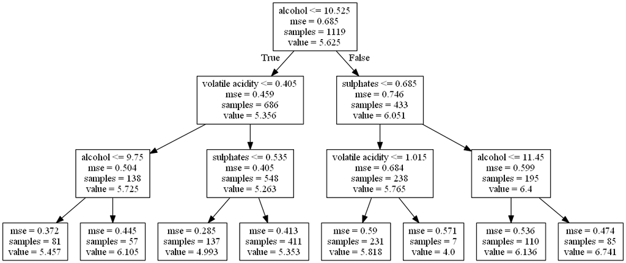

```python
import pydotplus
feature_names = [key for key in w_df]
dot_data = tree.export_graphviz(model, out_file=None,feature_names=feature_names[0:-1])
graph = pydotplus.graph_from_dot_data(dot_data)
graph.write_pdf("wines.pdf")
Image(graph.create_png())
#The tree will be saved to wines.pdf in your current directory
```

### Decision trees are Entropy minimizers

**Entropy**: a measure of uncertainty in the data

**Entropy minimization**: decision tree algorithms seek to partition the data on features in the way that total entropy is minimized

### Regression trees

Run regressions for each X to the dependent variable

Pick the variable with the most explanatory power and split it at several points

Calculate the Mean Square Error of each of the two halves for each split

Pick the split point that gives the lowest mse (combined)

## Cross validation

Split the training set into k smaller sets (aka folds)

Train the data on k-1 folds

Validate the results on fold k

Repeat this holding out each of the k folds in turn

Report the average of all tests as the performance metric

http://scikit-learn.org/stable/modules/cross_validation.html

```python
from sklearn.model_selection import cross_val_score
from sklearn.model_selection import KFold
```

```python
crossvalidation = KFold(n_splits=5,shuffle=True, random_state=1)
```

```python
from sklearn import tree
import numpy as np
for depth in range(1,10):
    model = tree.DecisionTreeRegressor(
    max_depth=depth, random_state=0)
    if model.fit(x_data,y_data).tree_.max_depth < depth:
        break
    score = np.mean(cross_val_score(model, x_data, y_data,scoring='neg_mean_squared_error', cv=crossvalidation, n_jobs=1))
    print ('Depth: %i Accuracy: %.3f' % (depth,score))
```

```
Depth: 1 Accuracy: -0.548
Depth: 2 Accuracy: -0.512
Depth: 3 Accuracy: -0.482
Depth: 4 Accuracy: -0.482
Depth: 5 Accuracy: -0.480
Depth: 6 Accuracy: -0.493
Depth: 7 Accuracy: -0.535
Depth: 8 Accuracy: -0.573
Depth: 9 Accuracy: -0.599
```

### Purpose of cross-validation

Not to generate a tree (it generates many trees!)

But to provide an estimate of the average error of the model

Roughly, the idea is to see how the model performance varies with different training sets

To generate the tree, use the entire training set as before

# Classification trees

## Classification trees are used when dealing with categorical dependent variables

Pick a variable and a split point so that the misclassification cost is the lowest.

### Rocks and mines data set

```python
import pandas as pd
from pandas import DataFrame
url="https://archive.ics.uci.edu/ml/machine-learning-databases/undocumented/connectionist-bench/sonar/sonar.all-data"
df = pd.read_csv(url,header=None)
df[60]=np.where(df[60]=='R',0,1)
df.describe()
```

|  | 0 | 1 | 2 | 3 | 4 | 5 | 6 | 7 | 8 | 9 | ... | 51 | 52 | 53 | 54 | 55 | 56 | 57 | 58 | 59 | 60 |
| --- | --- | --- | --- | --- | --- | --- | --- | --- | --- | --- | --- | --- | --- | --- | --- | --- | --- | --- | --- | --- | --- |
| count | 208.000000 | 208.000000 | 208.000000 | 208.000000 | 208.000000 | 208.000000 | 208.000000 | 208.000000 | 208.000000 | 208.000000 | ... | 208.000000 | 208.000000 | 208.000000 | 208.000000 | 208.000000 | 208.000000 | 208.000000 | 208.000000 | 208.000000 | 208.000000 |
| mean | 0.029164 | 0.038437 | 0.043832 | 0.053892 | 0.075202 | 0.104570 | 0.121747 | 0.134799 | 0.178003 | 0.208259 | ... | 0.013420 | 0.010709 | 0.010941 | 0.009290 | 0.008222 | 0.007820 | 0.007949 | 0.007941 | 0.006507 | 0.533654 |
| std | 0.022991 | 0.032960 | 0.038428 | 0.046528 | 0.055552 | 0.059105 | 0.061788 | 0.085152 | 0.118387 | 0.134416 | ... | 0.009634 | 0.007060 | 0.007301 | 0.007088 | 0.005736 | 0.005785 | 0.006470 | 0.006181 | 0.005031 | 0.500070 |
| min | 0.001500 | 0.000600 | 0.001500 | 0.005800 | 0.006700 | 0.010200 | 0.003300 | 0.005500 | 0.007500 | 0.011300 | ... | 0.000800 | 0.000500 | 0.001000 | 0.000600 | 0.000400 | 0.000300 | 0.000300 | 0.000100 | 0.000600 | 0.000000 |
| 25% | 0.013350 | 0.016450 | 0.018950 | 0.024375 | 0.038050 | 0.067025 | 0.080900 | 0.080425 | 0.097025 | 0.111275 | ... | 0.007275 | 0.005075 | 0.005375 | 0.004150 | 0.004400 | 0.003700 | 0.003600 | 0.003675 | 0.003100 | 0.000000 |
| 50% | 0.022800 | 0.030800 | 0.034300 | 0.044050 | 0.062500 | 0.092150 | 0.106950 | 0.112100 | 0.152250 | 0.182400 | ... | 0.011400 | 0.009550 | 0.009300 | 0.007500 | 0.006850 | 0.005950 | 0.005800 | 0.006400 | 0.005300 | 1.000000 |
| 75% | 0.035550 | 0.047950 | 0.057950 | 0.064500 | 0.100275 | 0.134125 | 0.154000 | 0.169600 | 0.233425 | 0.268700 | ... | 0.016725 | 0.014900 | 0.014500 | 0.012100 | 0.010575 | 0.010425 | 0.010350 | 0.010325 | 0.008525 | 1.000000 |
| max | 0.137100 | 0.233900 | 0.305900 | 0.426400 | 0.401000 | 0.382300 | 0.372900 | 0.459000 | 0.682800 | 0.710600 | ... | 0.070900 | 0.039000 | 0.035200 | 0.044700 | 0.039400 | 0.035500 | 0.044000 | 0.036400 | 0.043900 | 1.000000 |

8 rows × 61 columns

```python
from sklearn.model_selection import train_test_split
train, test = train_test_split(df, test_size = 0.3)
x_train = train.iloc[0:,0:60]
y_train = train[[60]]
x_test = test.iloc[0:,0:60]
y_test = test[[60]]

y_train.head()
```

|  | 60 |
| --- | --- |
| 45 | 0 |
| 178 | 1 |
| 165 | 1 |
| 133 | 1 |
| 204 | 1 |

```python
from sklearn.tree import DecisionTreeClassifier
from sklearn import tree

model = DecisionTreeClassifier(max_depth = 3,criterion='entropy')
model.fit(x_train,y_train)
```

```
DecisionTreeClassifier(class_weight=None, criterion='entropy', max_depth=3,
                       max_features=None, max_leaf_nodes=None,
                       min_impurity_decrease=0.0, min_impurity_split=None,
                       min_samples_leaf=1, min_samples_split=2,
                       min_weight_fraction_leaf=0.0, presort=False,
                       random_state=None, splitter='best')
```

```python
import pydotplus
feature_names = [key for key in df]
dot_data = tree.export_graphviz(model, out_file=None,feature_names=feature_names[:-1])
graph = pydotplus.graph_from_dot_data(dot_data)
graph.write_pdf("mines.pdf")
#The tree will be saved to mines.pdf in your current directory
```

```
True
```

```python
def confusion_matrix(predicted, actual, threshold):
    if len(predicted) != len(actual): return -1
    tp = 0.0
    fp = 0.0
    tn = 0.0
    fn = 0.0
    for i in range(len(actual)):
        if actual[i] > 0.5: #labels that are 1.0  (positive examples)
            if predicted[i] > threshold:
                tp += 1.0 #correctly predicted positive
            else:
                fn += 1.0 #incorrectly predicted negative
        else:              #labels that are 0.0 (negative examples)
            if predicted[i] < threshold:
                tn += 1.0 #correctly predicted negative
            else:
                fp += 1.0 #incorrectly predicted positive
    rtn = tn,fp,fn,tp

    return rtn
```

```python
import seaborn as sns
```

```python
p_train=model.predict(x_train)
p_test = model.predict(x_test)

cm_train_raw = confusion_matrix(p_train,np.array(y_train),.5)
cm_test_raw = confusion_matrix(p_test,np.array(y_test),.5)

cm_train = np.array(list(cm_train_raw)).reshape((2,2))
cm_test = np.array(list(cm_test_raw)).reshape((2,2))
```

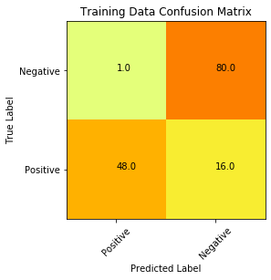

```python
plt.clf()
plt.imshow(cm_train,
          interpolation="nearest",
          cmap=plt.cm.Wistia)
plt.title("Training Data Confusion Matrix")
plt.ylabel("True Label")
plt.xlabel("Predicted Label")
classNames = ["Positive","Negative"]
tick_marks = np.arange(len(classNames))
plt.xticks(tick_marks,classNames,rotation=45)
plt.yticks(tick_marks,classNames)


for i in range(len(cm_train)):
    for j in range(len(cm_train)):
        plt.text(j,i,str(cm_train[i][j]))

plt.ylim(-0.5,1.5)
plt.show()
```

```python
def metrics(tuple_obj):
    tn,fp,fn,tp = tuple_obj
    precision = tp/(tp+fp)
    recall = tp/(tp+fn)
    fp_rate = fp/(tn+fp)
    f1_score = (2*(precision*recall))/(precision+recall)
    accuracy = (tp+tn)/(tp+fn+tn+fp)
    specificity = tn/(tn+fp)

    return precision,recall,fp_rate,f1_score,accuracy,specificity
```

Precision: $$\frac{\text{True Positives}}{\text{True Positives + False Positives}}$$

Recall (True-Positive Rate):$$\frac{\text{True Positives}}{\text{True Positives + False Negatives}}$$

False-Positive Rate: $$\frac{\text{False Positives}}{\text{True Negatives + False Positives}}$$

F1 Score (Average of Recall and Precision): $$\frac{\text{2 * (Precision * Recall)}}{\text{Precision + Recall}}$$

Accuracy: $$\frac{\text{True Positives + True Negatives}}{\text{True Positives + False Negatives + True Negatives + False Positives}}$$

Specificity: $$\frac{\text{True Negatives}}{\text{True Negatives + False Positives}}$$

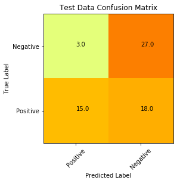

```python
plt.clf()
plt.imshow(cm_test,
          interpolation="nearest",
          cmap=plt.cm.Wistia)
plt.title("Test Data Confusion Matrix")
plt.ylabel("True Label")
plt.xlabel("Predicted Label")
classNames = ["Positive","Negative"]
tick_marks = np.arange(len(classNames))
plt.xticks(tick_marks,classNames,rotation=45)
plt.yticks(tick_marks,classNames)


for i in range(len(cm_test)):
    for j in range(len(cm_test)):
        plt.text(j,i,str(cm_test[i][j]))

plt.ylim(-0.5,1.5)
plt.show()
```

```python
print("Precision: ",metrics(cm_test_raw)[0])
print("Recall: ",metrics(cm_test_raw)[1])
print("False-Positive Rate: ",metrics(cm_test_raw)[2])
print("F1 Score: ",metrics(cm_test_raw)[3])
print("Accuracy: ",metrics(cm_test_raw)[4])
print("Specificity: ",metrics(cm_test_raw)[5])
```

```
Precision:  0.6
Recall:  0.9
False-Positive Rate:  0.5454545454545454
F1 Score:  0.7200000000000001
Accuracy:  0.6666666666666666
Specificity:  0.45454545454545453
```

[figure not shown]

```python
from sklearn.metrics import roc_curve,auc
import pylab as pl
%matplotlib inline
(fpr, tpr, thresholds) = roc_curve(y_train,p_train)
area = auc(fpr,tpr)
pl.clf() #Clear the current figure
pl.plot(fpr,tpr,label="In-Sample ROC Curve with area = %1.2f"%area)

pl.plot([0, 1], [0, 1], 'k') #This plots the random (equal probability line)
pl.xlim([0.0, 1.0])
pl.ylim([0.0, 1.0])
pl.xlabel('False Positive Rate')
pl.ylabel('True Positive Rate')
pl.title('In sample ROC rocks versus mines')
pl.legend(loc="lower right")
pl.show()
```

```python
fpr,tpr,thresholds
```

[output not shown]

[figure not shown]

```python
from sklearn.metrics import roc_curve,auc
import pylab as pl
%matplotlib inline
(fpr, tpr, thresholds) = roc_curve(y_test,p_test)
area = auc(fpr,tpr)
pl.clf() #Clear the current figure
pl.plot(fpr,tpr,label="Out-Sample ROC Curve with area = %1.2f"%area)

pl.plot([0, 1], [0, 1], 'k') #This plots the random (equal probability line)
pl.xlim([0.0, 1.0])
pl.ylim([0.0, 1.0])
pl.xlabel('False Positive Rate')
pl.ylabel('True Positive Rate')
pl.title('Out sample ROC rocks versus mines')
pl.legend(loc="lower right")
pl.show()
```